# **TIME SERIES - FINAL PROJECT**

### August 14th, 2019

**Import necessary libraries**

```r
library(readxl)
library(tseries)
library(ggplot2)
library(fpp)
library(TSA)
library(MuMIn)
library(stats)
library(forecast)
library(dplyr)
library(Metrics)
library(vars)
library(lubridate)
```

Set working directory

```r
datapath <- "C:/Users/Nick/Desktop/time_series/Final_Project"
setwd(datapath)
```

Read in data and fix some issues with columns, names, etc.

```r
avocado <- read.table("avocado.csv", header=TRUE, sep = ",")

# delete index and date row
avocado <- avocado[which(avocado$region == "Chicago" & avocado$type == "conventional"),-1]

# change column names
colnames(avocado) <- c("Date", "AveragePrice", "TotalVolume",
                       "SmallHaasVolume", "LargeHaasVolume",
                       "XtraLargeHaasVolume", "TotalBags",
                       "SmallBags", "LargeBags", "XtraLargeBags",
                       "Type", "Year", "Region")

# order by Date ascending
avocado <- avocado[order(avocado$Date),]
rownames(avocado) <- 1:nrow(avocado)
```

```r
avocado.ts <- ts(avocado["TotalVolume"], freq=365.25/7,
                 start=decimal_date(ymd("2015-01-04")))
```

Plot avocado.ts

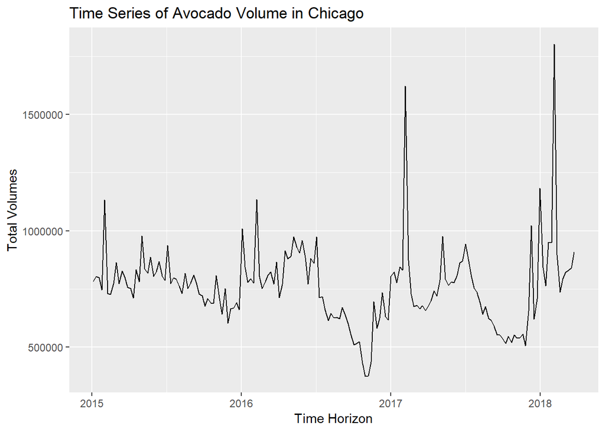

```r
autoplot(avocado.ts, xlab="Time Horizon", ylab="Total Volumes",
         main="Time Series of Avocado Volume in Chicago")
```

Let’s create a training set with first 154 weeks and a test set with 15 weeks 2017-12-10

```r
train.avocado.ts <- window(avocado.ts, decimal_date(ymd("2015-01-04")), decimal_date(ymd("2017-12-17")))
test.avocado.ts <- window(avocado.ts, decimal_date(ymd("2017-12-17")))
```

Augmented Dickey-Fuller Test to check for stationarity in the training set.

```r
adf.test(train.avocado.ts)
```

```
##
##  Augmented Dickey-Fuller Test
##
## data:  train.avocado.ts
## Dickey-Fuller = -3.2561, Lag order = 5, p-value = 0.08114
## alternative hypothesis: stationary
```

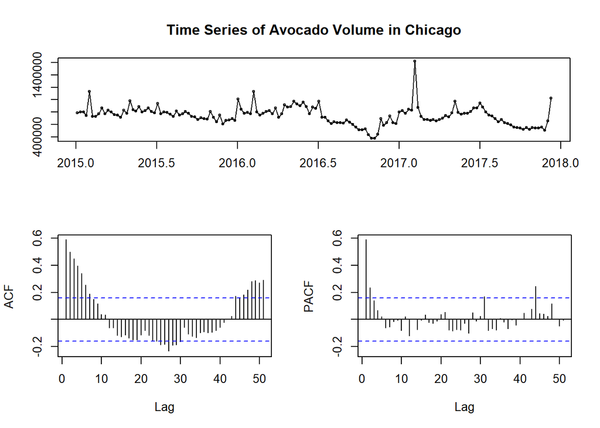

```r
tsdisplay(train.avocado.ts, main="Time Series of Avocado Volume in Chicago")
```

Looks like there is some significant autocorrelation in the series. Let’s try taking the first difference.

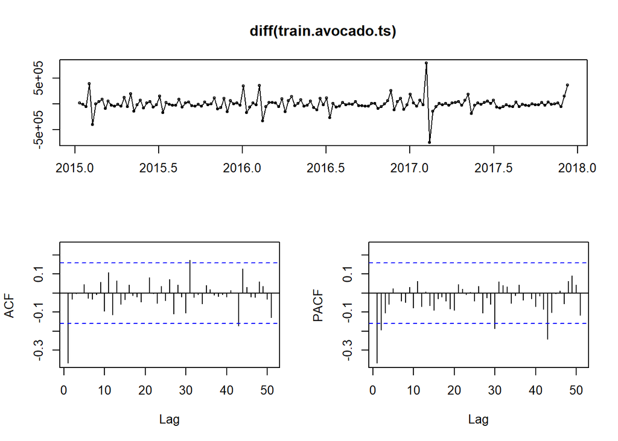

```r
tsdisplay(diff(train.avocado.ts))
```

Now let’s use auto.arima to fit a model on the training data.

```r
(fit.auto <- auto.arima(train.avocado.ts, seasonal = TRUE, max.p = 2, max.q = 2, max.P = 2, max.Q = 2,
                        allowdrift = TRUE, num.cores = 4, d=1))
```

```
## Series: train.avocado.ts
## ARIMA(1,1,1)(0,1,0)[52]
##
## Coefficients:
##          ar1      ma1
##       0.2150  -0.8078
## s.e.  0.1743   0.1246
##
## sigma^2 estimated as 1.576e+10:  log likelihood=-1328.35
## AIC=2662.71   AICc=2662.95   BIC=2670.55
```

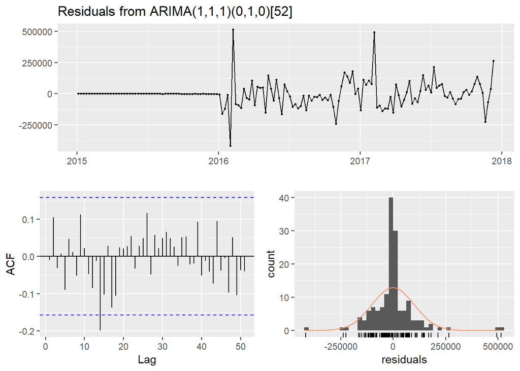

```
##
##  Ljung-Box test
##
## data:  Residuals from ARIMA(1,1,1)(0,1,0)[52]
## Q* = 28.658, df = 29, p-value = 0.483
##
## Model df: 2.   Total lags used: 31
```

```r
checkresiduals(fit.auto)
```

That looks pretty good.

Let’s run the forcasting function on the training set for 15 weeks.

```r
foreCaster<- forecast::forecast
fcast <-foreCaster(fit.auto, h=15, level=c(50, 95))
```

Plot the forecast and overlay the test set values

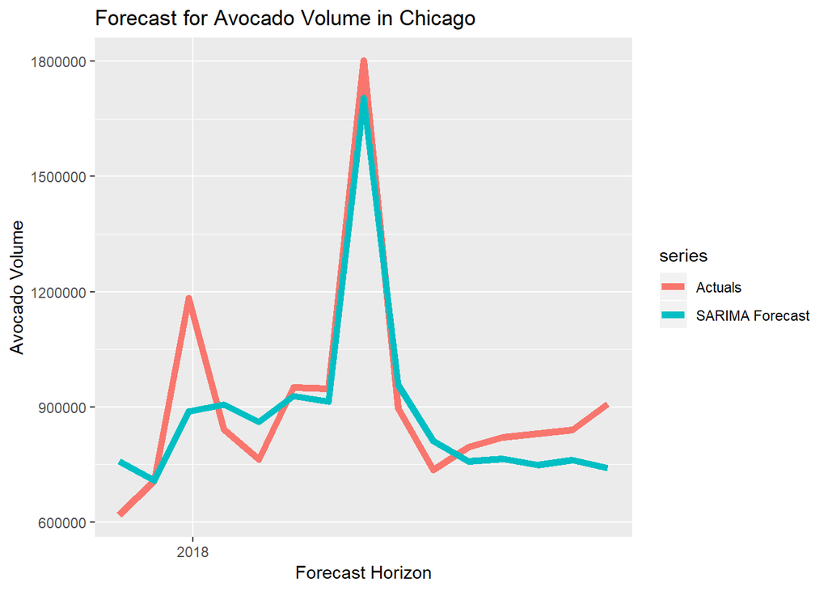

```r
autoplot(test.avocado.ts, series="Actuals", lwd=2) +
  autolayer(fcast$mean, series="SARIMA Forecast", lwd=2) +
  ggtitle("Forecast for Avocado Volume in Chicago") +
  xlab("Forecast Horizon") + ylab("Avocado Volume")
```

That look’s really strong. Let’s calculate some metrics to see how the model performed against the test set.

```r
foreCastAccuracy<-forecast::accuracy
foreCastAccuracy(fcast$mean, test.avocado.ts)
```

```
##                ME     RMSE      MAE      MPE     MAPE         ACF1
## Test set 28473.47 111042.3 87128.72 1.659274 9.690058 -0.007388399
##          Theil's U
## Test set 0.3983479
```

**Our model has a mean % error of 9.7% which is within the acceptable accuracy threshold.**